# Przetwarzanie, analiza i wizualizacja danych przestrzennych w języku R

Kurs Uniwersytetu Otwartego UAM  
Zajęcia 4 - Rastry

Author

**Adrian Nowacki** (adrian.nowacki@amu.edu.pl)

Published

April 16, 2025

# Wprowadzenie

Przetwarzanie danych rastrowych można wykonać za pomocą tego samego pakietu, co przetwarzanie danych wektorowych – pakietu `terra`. Wizualizacja w postaci map także odbywa się głównie dzięki dwóm pakietom – `ggplot2` oraz `tmap`. Na potrzeby kursu skorzystamy również z przykładowego zbioru dla Luksemburga z pakietu `terra` – tym razem będzie to raster z wysokością rzeźby terenu.

### Wczytywanie, zapisywanie i proste wizualizacje

```r
library(tidyverse)
library(terra)

# sprawdzenie testowych plików
list.files(system.file("ex", package = "terra"))
```

```
 [1] "countries.rds"      "elev.tif"           "elev_vinschgau.tif"
 [4] "logo.tif"           "lux.dbf"            "lux.prj"
 [7] "lux.shp"            "lux.shx"            "meuse.rds"
[10] "meuse.tif"          "rds_tst.rds"        "test.grd"
[13] "test.gri"
```

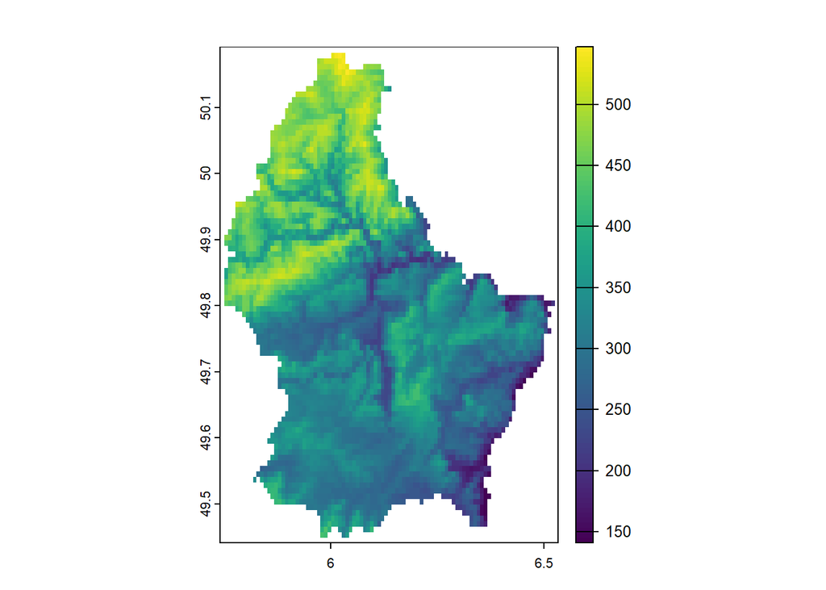

```r
sciezka_do_pliku <- system.file("ex/elev.tif", package = "terra")
luksemburg <- rast(sciezka_do_pliku)

luksemburg <- rast(sciezka_do_pliku, lyrs = 1)   # przykładowy wybór 1 kanału – w tym przypadku jedynego

plot(luksemburg)
```

Szczegóły warstwy można sprawdzić za pomocą uruchomienia nazwy obiektu – w wyniku otrzymujemy informacje o:

- klasie obiektu
- wymiarach (liczba wierszy, liczba kolumn, liczba kanałów)
- rozdzielczości poziomej oraz pionowej
- zakresie warstwy (bbox)
- układzie współrzędnych
- ścieżce i nazwie pliku
- maksymalnej i minimalnej wartości

```r
luksemburg
```

```
class       : SpatRaster
dimensions  : 90, 95, 1  (nrow, ncol, nlyr)
resolution  : 0.008333333, 0.008333333  (x, y)
extent      : 5.741667, 6.533333, 49.44167, 50.19167  (xmin, xmax, ymin, ymax)
coord. ref. : lon/lat WGS 84 (EPSG:4326)
source      : elev.tif
name        : elevation
min value   :       141
max value   :       547
```

Do zapisania pliku służy bardzo podobna funkcja, co w przypadku wektorów – `writeRaster()`. Może ona przyjmować dodatkowe argumenty m.in. dla zdefiniowania typu danych, czy nadpisania istniejącego pliku.

```r
writeRaster(luksemburg, "luksemburg.tif")
writeRaster(luksemburg, "luksemburg.tif", datatype = "INT1U", overwrite = FALSE)
```

### Typy danych rastrowych

Typy danych rastrowych określają sposób przechowywania wartości w pikselach – czy są one liczbami całkowitymi, zmiennoprzecinkowymi, dodatnimi bądź ujemnymi, a także ile bitów zajmuje każdy piksel.

Wśród nich wyróżniamy:

Typy te są stosowane w celu zmniejszenia rozmiaru plików i przyspieszenia obliczeń, np. mając raster z pokryciem terenu przez zabudowę z wartościami binarnymi (TRUE lub FALSE), nie ma potrzeby używania typu zmiennoprzecinkowego (*FLT4S*). Wystarczy zastosować typ *INT1U*, który może przechowywać wartości od 0 do 255 – w zupełności wystarczające do zakodowania wartości 0 (brak zabudowy) i 1 (zabudowa).

W języku R do sprawdzenia typu danych rastrowych stosuje się funkcję `datatype()`:

```r
datatype(luksemburg)
```

```
[1] "INT2S"
```

# Rastry

### Tworzenie rastrów

Oprócz samego wczytywania danych rastrowych, funkcja `rast()` służy także do tworzenia rastrów, co może być przydatne np. w celu przypisania danych punktowych do komórek siatki (pikseli rastra). Za pomocą funkcji `ncell()` można zliczyć liczbę wszystkich komórek rastra (pikseli), za pomocą `rnorm()` wylosować wartości dla zadanej liczby pikseli, a za pomocą funkcji `values()` przypisać wylosowane wartości do rastra. Jeśli nie wiadomo, czy raster ma jakiekolwiek wartości, można to sprawdzić za pomocą `hasValues()`.

```r
set.seed(100) # ustawienie ziarna losowości

raster = rast(nrows = 40, ncols = 20, xmin = -50, xmax = 50, ymin = -90, ymax = 90,
              crs = "EPSG:4326")
hasValues(raster)
```

```
[1] FALSE
```

```r
liczba_px = ncell(raster)
wartosci = rnorm(liczba_px)
values(raster) <- wartosci
hasValues(raster)
```

```
[1] TRUE
```

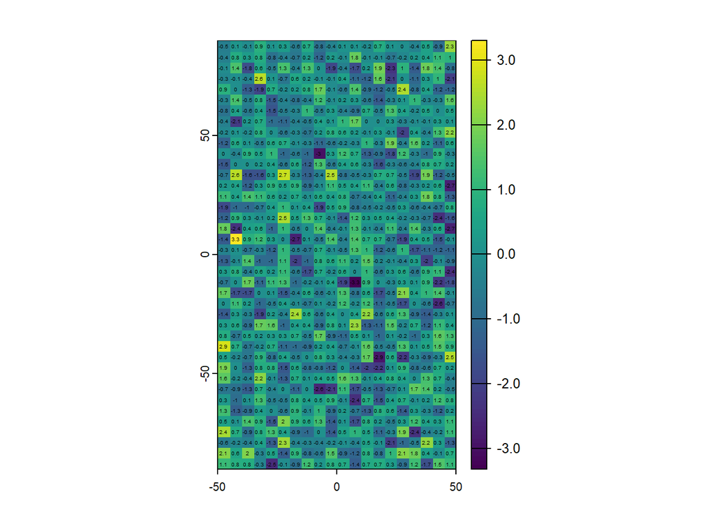

```r
plot(raster)
text(raster, cex = 0.3, digits = 1)    # dodanie etykiet pikseli
```

Można także stworzyć nowy raster w oparciu o detale warstwy *luksemburg*, gdzie definiujemy identyczną rozdzielczość, zakres oraz układ współrzędnych:

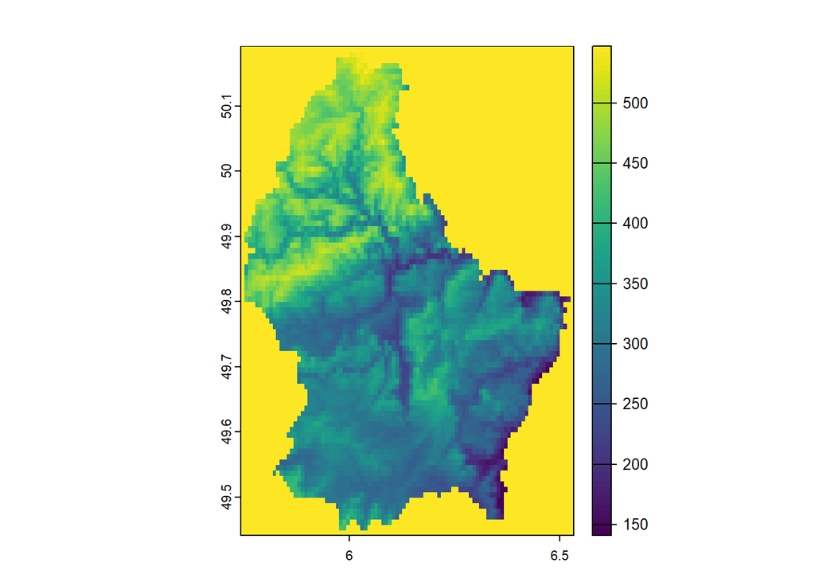

```r
raster_1 <- rast(res = res(luksemburg), ext = ext(luksemburg), crs = crs(luksemburg))
values(raster_1) <- 100
plot(raster_1, legend = FALSE)
plot(luksemburg, add = TRUE)
```

Korzystając z podstawowej funkcji `plot()` pakietu terra możemy wizualizować kilka warstw jednocześnie, ale także osobno. Najprostszym sposobem jest wypisanie warstw w wektorze:

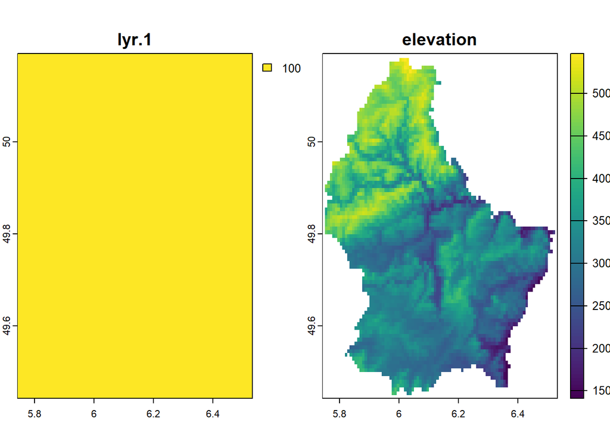

```r
plot(c(raster_1, luksemburg))
```

### Konwersja rastrów

Oprócz wczytywania i tworzenia danych rastrowych, funkcja `rast()` ma także jeszcze inne zastosowanie. Pozwala ona na konwersję innych typów danych do postaci rastrowej, m.in. ramek danych i macierzy, jeśli te mają poprawną strukturę. Co więcej, każdy raster można także konwertować zarówno do ramki danych, jak i macierzy.

Poniżej zaprezentowano przykład dla konwersji rastra na ramkę danych. Należy zwrócić uwagę, że bez wskazania geometrii przy konwersji, do ramki danych zapiszą się jedynie wartości rastra, dlatego należy pamiętać o stosowaniu parametru `xy = TRUE`.

```r
luksemburg_df <- as.data.frame(luksemburg)
head(luksemburg_df)
```

```
    elevation
127       529
128       542
129       547
130       535
218       485
219       497
```

```r
luksemburg_df <- as.data.frame(luksemburg, xy = TRUE)
head(luksemburg_df)
```

```
           x        y elevation
127 6.004167 50.17917       529
128 6.012500 50.17917       542
129 6.020833 50.17917       547
130 6.029167 50.17917       535
218 5.970833 50.17083       485
219 5.979167 50.17083       497
```

Przy konwersji ramki danych na raster należy mieć na uwadze, że ramka danych powinna wyglądać odpowiednio – posiadać współrzędne X i Y (centroidy komórek rastra) oraz wartość zmiennej w trzeciej kolumnie.

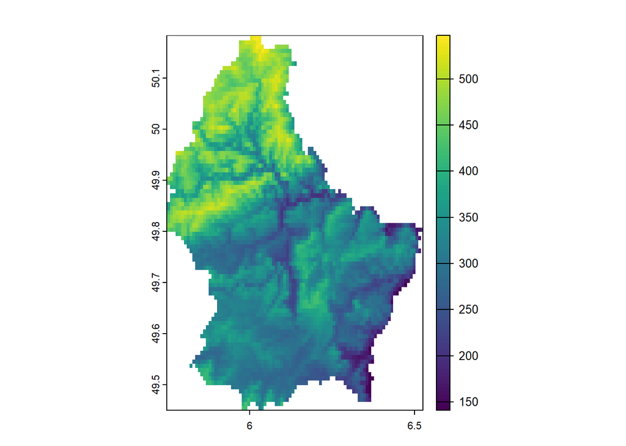

```r
luksemburg_rast <- rast(luksemburg_df, type="xyz", crs="epsg:4326")
plot(luksemburg_rast)
```

Poniżej zaprezentowano przykład dla konwersji rastra na macierz. Warto zwrócić uwagę na parametr `wide=TRUE`, który oznacza odzwierciedlenie identycznej struktury rastra, to znaczy każdy wiersz będzie osobnym wierszem w macierzy, a każda kolumna rastra osobną kolumną macierzy. Po każdej konwersji typów danych na raster informacja o układzie współrzędnych rastra jest usuwana, dlatego warto od razu dodać informacje o układzie współrzędnych docelowej warstwy.

```r
luksemburg_matrix <- as.matrix(luksemburg, wide = TRUE)
luksemburg_matrix[20:24, 10:14]
```

```
     [,1] [,2] [,3] [,4] [,5]
[1,]   NA   NA   NA   NA   NA
[2,]   NA   NA   NA   NA  446
[3,]   NA  440  422  407  425
[4,]   NA  413  400  409  461
[5,]   NA  484  487  450  394
```

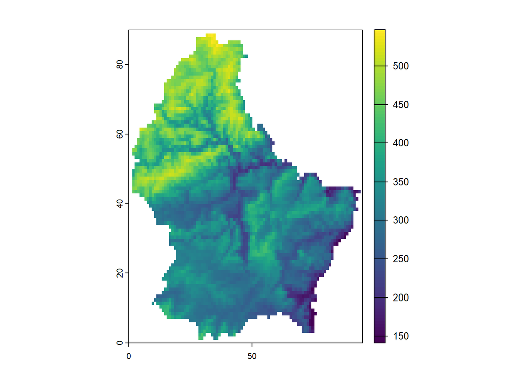

```r
luksemburg_rast <- rast(luksemburg_matrix, crs = "epsg:4326")
plot(luksemburg_rast)
```

### Reprojekcja

Tak jak w przypadku danych wektorowych, przy wykorzystaniu pakietu `terra` operacje na układach współrzędnych są identyczne także dla rastrów. Do sprawdzenia i przypisania układu współrzędnych (w przypadku jego braku) służy funkcja `crs()`, natomiast do projekcji na inny układ współrzędnych – funkcja `project()`.

```r
crs(luksemburg, describe=TRUE)
```

```
    name authority code  area             extent
1 WGS 84      EPSG 4326 World -180, 180, -90, 90
```

```r
luksemburg_proj <- project(luksemburg, "epsg:3857")
crs(luksemburg_proj, describe=TRUE)
```

```
                      name authority code                              area
1 WGS 84 / Pseudo-Mercator      EPSG 3857 World between 85.06°S and 85.06°N
                          extent
1 -180.00, 180.00, -85.06, 85.06
```

Jeśli chcemy w prosty sposób zwizualizować dwie mapy obok siebie, aby zobaczyć wizualne różnice po projekcji, samo użycie funkcji `plot()` nie wystarczy, ponieważ funkcja ta wymaga, aby wszystkie obiekty miały ten sam układ współrzędnych oraz zasięg (po projekcji zostało to zmienione). Do poprawnej wizualizacji przyda się tutaj funkcja `par()`, służąca do prostego łączenia grafik w jedną. Parametr `mfrow` określa odpowiednio liczbę wierszy i kolumn ostatecznej grafiki.

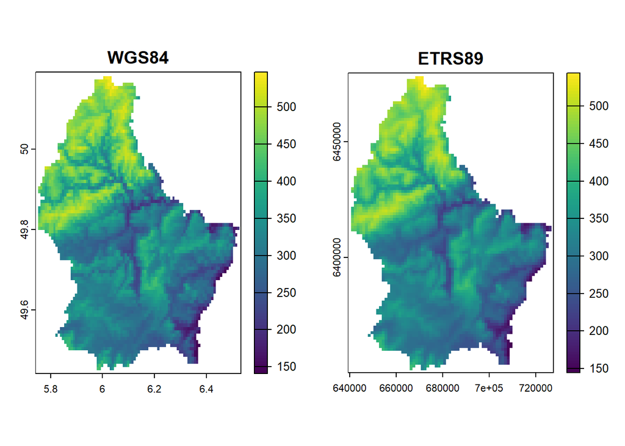

```r
par(mfrow = c(1, 2))
plot(luksemburg, main = "WGS84")
plot(luksemburg_proj, main = "ETRS89")
```

Możemy zauważyć, że w przypadku naszego zbioru dla Luksemburga zmiana układu współrzędnych prowadzi do lekkich różnic zarówno w wizualizacji, jak i wartości rastra. Mając dane prezentujące zmienną ciągłą, np. wysokość rzeźby terenu, lekkie zmiany wartości rastra nie są ogromną przeszkodą. Mając jednak dane dyskretne, np. z numerami odpowiadającymi poszczególnym kategoriom pokrycia terenu (np. 1 – zabudowa, 2 – lasy, itd.), projekcja może wpłynąć na zmianę komórek rastra tak, że uzyskamy np. wartości zmiennoprzecinkowe (z piksela oznaczającego zabudowę (1) zrobi się piksel z wartością 1.284). Aby temu zapobiec, należy użyć odpowiedniej metody przekształcania wartości pikseli, które są powszechne m.in. przy wykonywaniu georeferencji, projekcji, czy też zmiany rozdzielczości danych.

Metody te możemy sprawdzić w dokumentacji funkcji za pomocą `?project()`. Wyróżniamy:

- **bilinear** – interpolacja dwuliniowa, średnia ważona z 9 najbliższych komórek (3x3) (dla danych ciągłych, np. temperatury, wysokości, zmienia wartości komórek po przekształceniu)
- **average** – średnia ważona wartości pokrywających się komórek
- **near** – przybiera wartość najbliższego sąsiedniego piksela
- **mode** – moda, najczęściej występująca wartość
- **cubic** – interpolacja sześcienna (5x5 komórek)
- **cubicspline** – interpolacja sześcienna (5x5) kładąca nacisk na większe “wygładzenie” wartości
- **lanczos** – interpolacja wysokiej jakości (7x7 komórek)
- **sum, min, max, median, q1, q3** – statystyki z wielu komórek

Wśród wszystkich wymienionych metod, jedynie `near` oraz `mode` nie zmieniają wartości komórek rastra, więc stosuje się je do danych kategorycznych (np. klas pokrycia terenu).

### Zmiana rozdzielczości

Często zdarza się, że rozdzielczość przestrzenna rastra jest zbyt niska lub zbyt wysoka, aby wykonać poprawną analizę. Zbyt niska rozdzielczość może wpływać na niezbyt szczegółowe rezultaty, natomiast zbyt wysoka może stwarzać wiele problemów obliczeniowych.

Do sprawdzenia rozdzielczości przestrzennej rastra służy funkcja `res()`. Informację o rozdzielczości mamy także podaną w szczegółach obiektu. Należy pamiętać, że rozdzielczość ta jest zawsze podawana w tych samych jednostkach, których używa układ współrzędnych

```r
res(luksemburg)
```

```
[1] 0.008333333 0.008333333
```

```r
luksemburg
```

```
class       : SpatRaster
dimensions  : 90, 95, 1  (nrow, ncol, nlyr)
resolution  : 0.008333333, 0.008333333  (x, y)
extent      : 5.741667, 6.533333, 49.44167, 50.19167  (xmin, xmax, ymin, ymax)
coord. ref. : lon/lat WGS 84 (EPSG:4326)
source      : elev.tif
name        : elevation
min value   :       141
max value   :       547
```

Z pomocą przychodzą dwie główne funkcje, pozwalające zmienić rozdzielczość danych rastrowych – funkcja `aggregate()` (poznana na poprzednich zajęciach) zmniejsza rozdzielczość (komórki rastra są większe i mniej szczegółowe), natomiast funkcja `disagg()` zwiększa rozdzielczość (komórki są mniejsze i przekazują więcej informacji). Dezagregację nazywamy “*upsamplingiem*”, natomiast agregację – “*downsamplingiem*”.

```r
luksemburg_agg = aggregate(luksemburg, fact = 3, fun = "mean")
res(luksemburg_agg)
```

```
[1] 0.025 0.025
```

```r
luksemburg_disagg = disagg(luksemburg, fact = 3, method = "bilinear")
res(luksemburg_disagg)
```

```
[1] 0.002777778 0.002777778
```

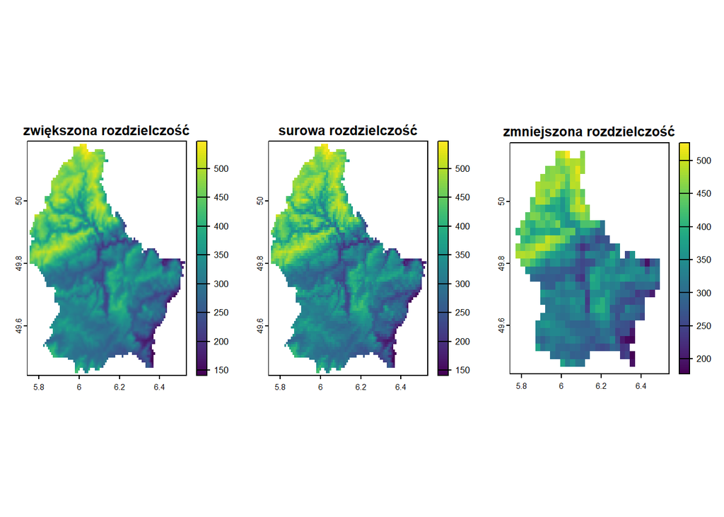

```r
par(mfrow = c(1, 3))
plot(luksemburg_disagg, main = "zwiększona rozdzielczość")
plot(luksemburg, main = "surowa rozdzielczość")
plot(luksemburg_agg, main = "zmniejszona rozdzielczość")
```

Istnieje także funkcja `resample()`, która dopasowuje jeden raster do drugiego, zarówno pod względem siatki pikseli, jak i zasięgu oraz rozdzielczości. Jest szczególnie przydatna, kiedy posiadamy rastry w tym samym układzie współrzędnych, natomiast nie możemy ich analizować razem ze względu na inne rozdzielczości.

Poniżej dla przykładu zaprezentowano resampling oryginalnego rastra wysokości `luksemburg` do siatki próbnego rastra, odznaczającego się zupełnie inną rozdzielczością.

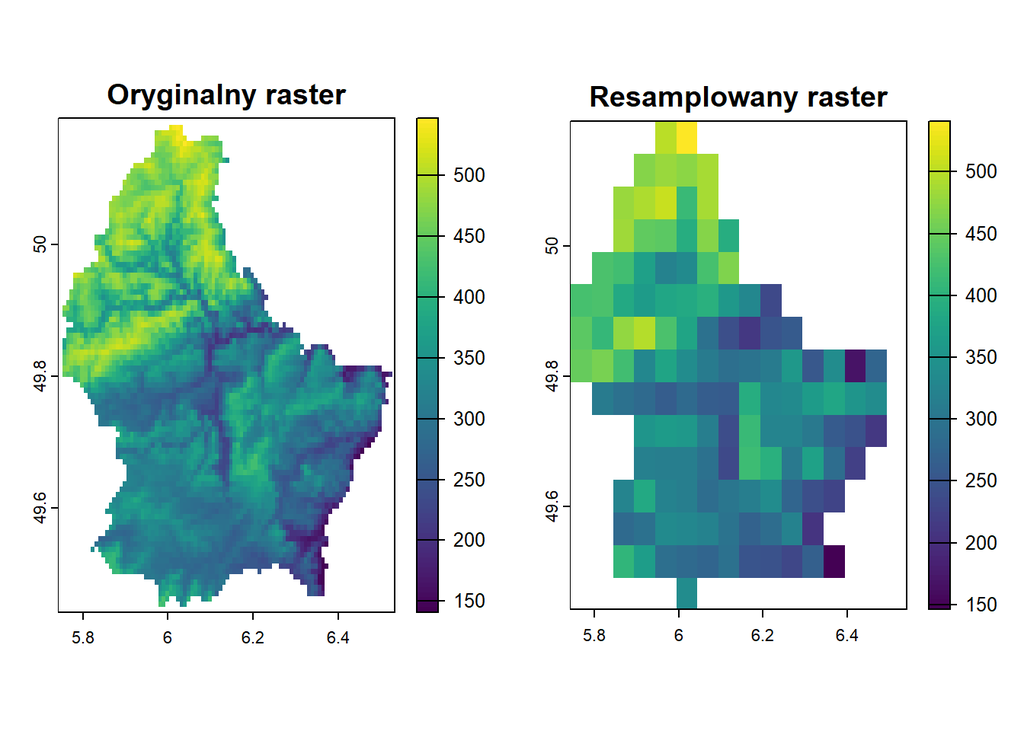

```r
# utworzenie pustego rastra o większej rozdzielczości
raster_2 <- rast(res = 0.05, ext = ext(luksemburg), crs = crs(luksemburg))

# resampling do nowej siatki (dopasowanie luksemburgu do rastra)
luksemburg_resampled <- resample(luksemburg, raster_2, method = "near")

par(mfrow = c(1, 2))
plot(luksemburg, main = "Oryginalny raster")
plot(luksemburg_resampled, main = "Resamplowany raster")
```

### Reklasyfikacja

Reklasyfikacja rastra jest odzwierciedleniem reklasyfikacji na danych wektorowych, bądź też ramkach danych. Mając raster zarówno ze zmienną ciągłą, jak i kategoryczną, za pomocą funkcji `classify()` jesteśmy w stanie zreklasyfikować ją do innych wartości (klas). Głównym parametrem funkcji jest tabela z określonymi zakresami reklasyfikacji, składająca się z trzech wartości dla liczby wierszy zależnej od tego, ile klas chcemy wyodrębnić. Wartościami w tabeli są zakresy: dolny przedział wartości, górny przedział wartości, a także docelowa nowa wartość.

Mając przykładowy raster z wysokością rzeźby terenu jesteśmy w stanie zreklasyfikować go np. do 3 klas podziału fizjograficznego na niziny, wzniesienia i wyżyny:

```r
# utworzenie tabeli reklasyfikacji (musi być macierzą)
tabela_reklasyfikacji <- matrix(c(0, 200, 1,                 # 1 klasa - od 0 do 200 metrów wartość 1
                                  200, 400, 2,               # 2 klasa - od 200 do 400 metrów wartość 2
                                  400, Inf, 3),              # 3 klasa - od 0 do 200 metrów wartość 3
                                  ncol = 3, byrow = TRUE)    # określenie liczby kolumn i tworzenie wierszami
tabela_reklasyfikacji
```

```
     [,1] [,2] [,3]
[1,]    0  200    1
[2,]  200  400    2
[3,]  400  Inf    3
```

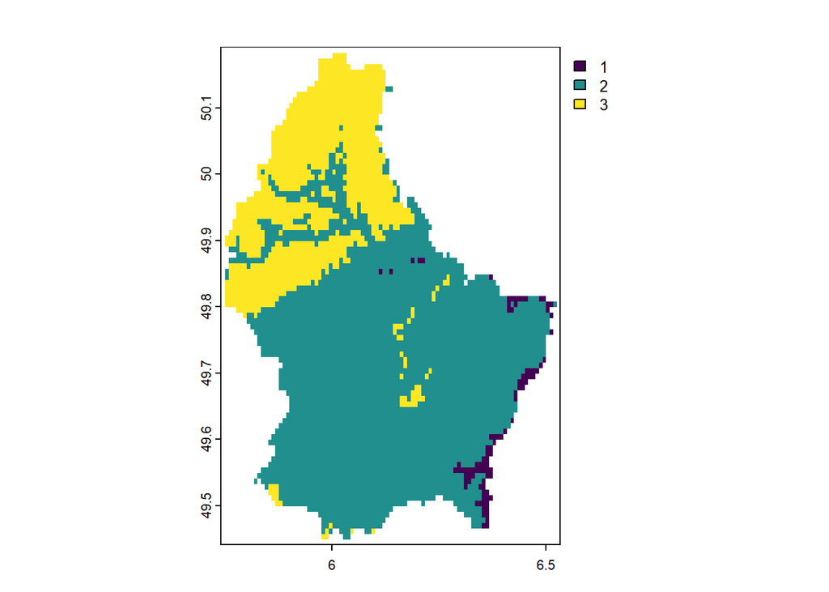

```r
luksemburg_reclass <- classify(luksemburg, tabela_reklasyfikacji, others = NULL)    # NULL dla pozostałych wartości (jeśli są)
plot(luksemburg_reclass)
```

##### Kategoryzacja

```r
levels(luksemburg_reclass)
```

```
[[1]]
[1] ""
```

```r
levels(luksemburg_reclass) <- data.frame(value = 1:3,
                                         label = c("Niziny", "Wzniesienia", "Wyżyny"))
levels(luksemburg_reclass)
```

```
[[1]]
  value       label
1     1      Niziny
2     2 Wzniesienia
3     3      Wyżyny
```

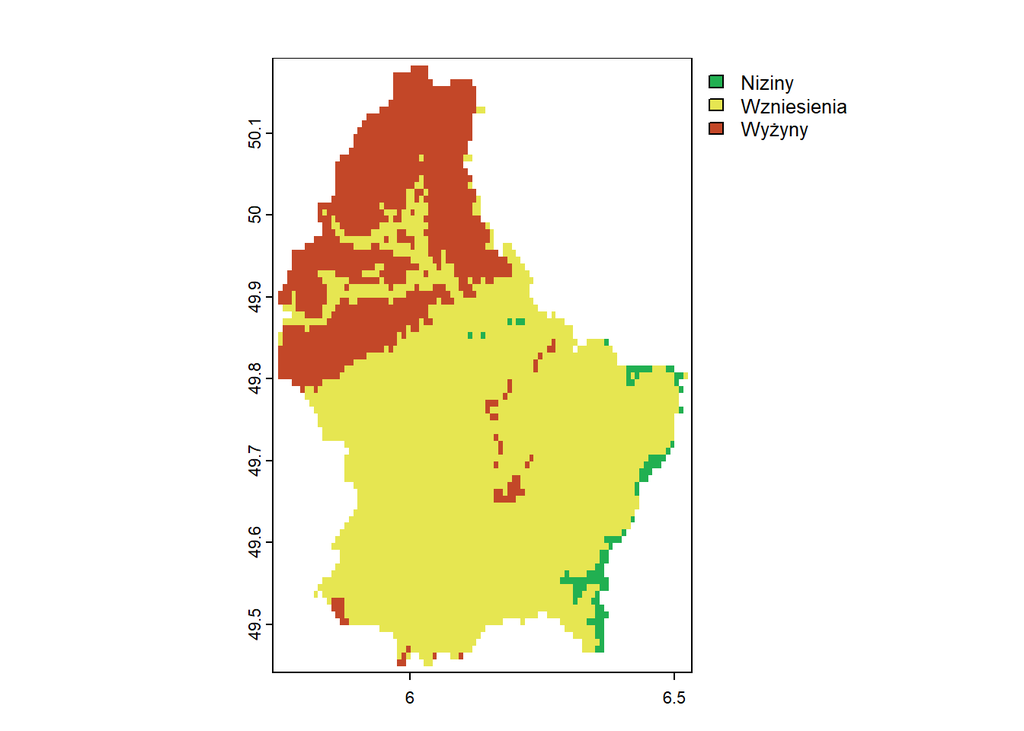

```r
plot(luksemburg_reclass, col = c("#21b051", "#e6e651", "#c34728"))
```

### Algebra

Dane rastrowe mają strukturę macierzy, co usprawnia wszelkie działania na rastrach – operacje logiczne, matematyczne i algebraiczne. Algebra rastrów jest niezwykle przydatna przede wszystkim w modelowaniu zjawisk środowiskowych, analizie zmian pokrycia terenu, czy analizie wielokryterialnej, gdzie bierze się pod uwagę wiele warstw spełniających określone kryteria.

Na rastrach można wykonać m.in.:

- wyodrębniać wartości spełniające dany warunek logiczny

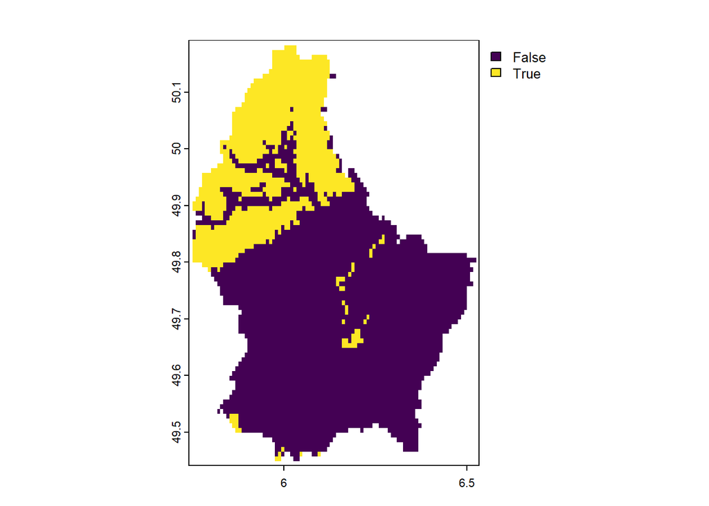

```r
raster_pow_400 <- luksemburg > 400
plot(raster_pow_400)
```

- wszelkie podstawowe operacje matematyczne (dodawanie, odejmowanie, mnożenie itd.)

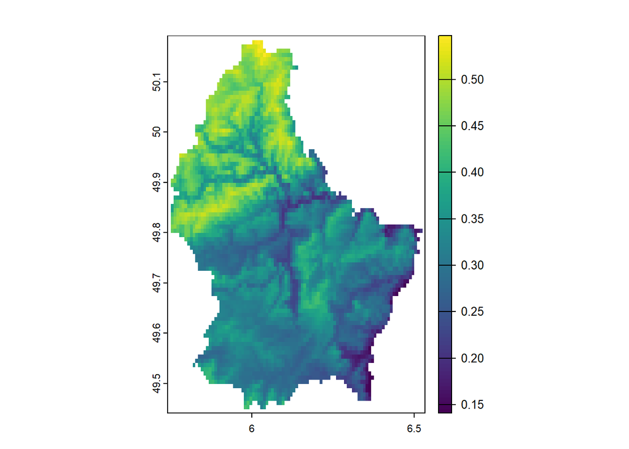

```r
raster_km <- luksemburg / 1000
plot(raster_km)
```

- wszelkie operacje na rastrach

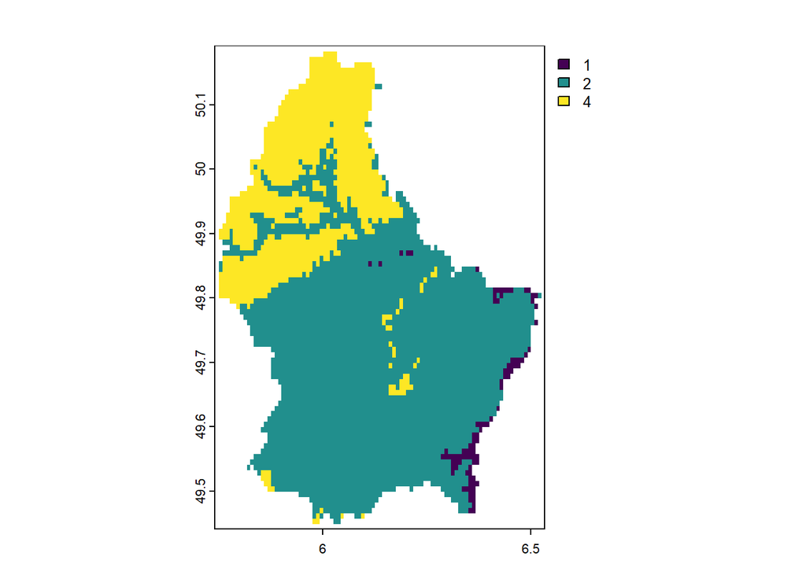

```r
suma <- raster_pow_400 + luksemburg_reclass
plot(suma)
```

### Przycinanie i maskowanie

Tak samo jak dane wektorowe, rastry mogą być przycinane do wybranego obszaru – innej warstwy rastrowej, warstwy wektorowej, czy też utworzonego zasięgu (extent). Do przycinania rastrów służy funkcja `crop()`, natomiast do maskowania, które ukrywa przycięte obszary – funkcja `mask()`.

- przycięcie do zasięgu:

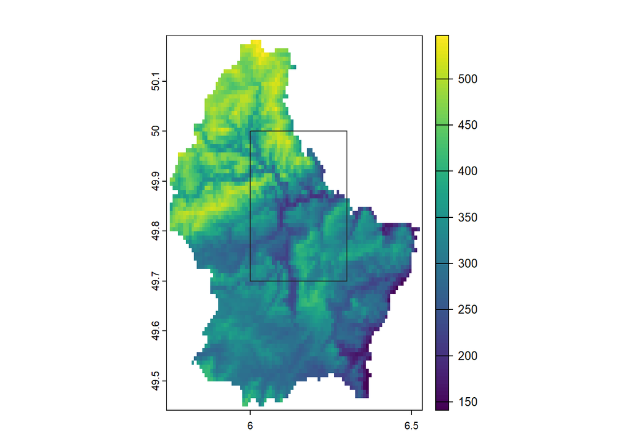

```r
extent <- ext(6, 6.3, 49.7, 50)
plot(luksemburg)
plot(extent, border = "#222222", add = TRUE)
```

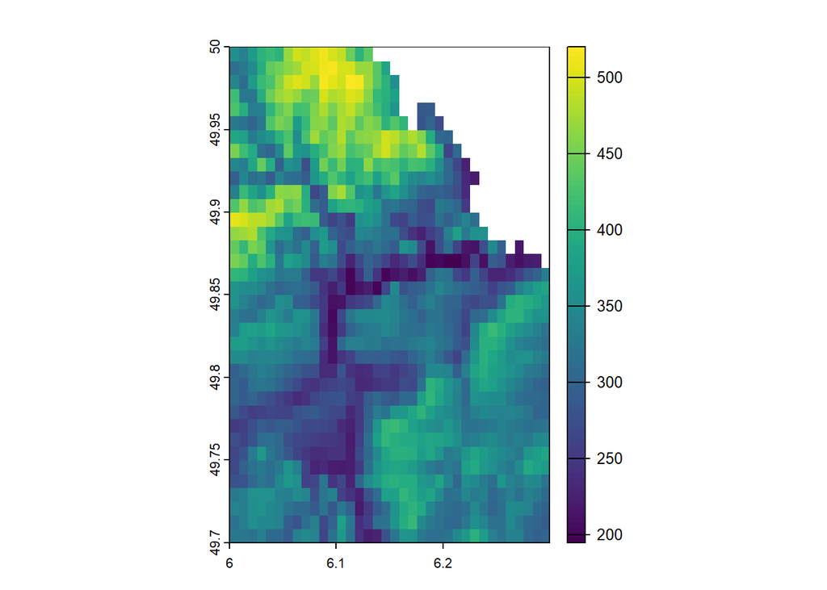

```r
przyciety_1 <- crop(luksemburg, extent)
plot(przyciety_1)
```

- przycięcie do warstwy wektorowej (UWAGA: raster przycinany do nieregularnego kształtu zawsze należy dodatkowo zamaskować, ponieważ docięty raster jest wyświetlany dla zakresu warstwy przycinającej)

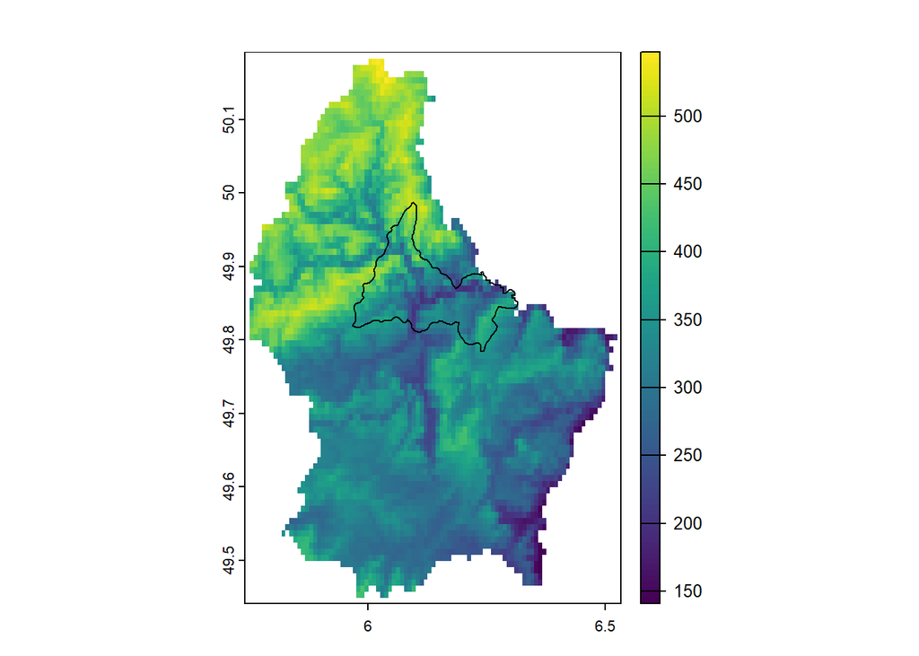

```r
kantony <- vect(system.file("ex/lux.shp", package = "terra"))
kantony_wybrane <- kantony[kantony$NAME_2 == "Diekirch"]
plot(luksemburg)
plot(kantony_wybrane, add=TRUE)
```

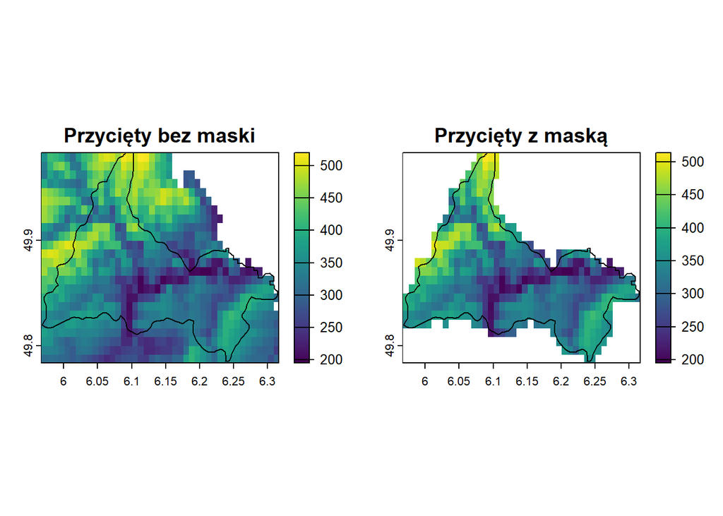

```r
przyciety_2 <- crop(luksemburg, kantony_wybrane)
przyciety_2_maska <- crop(luksemburg, kantony_wybrane, mask=TRUE) # można użyć także funkcji mask()

par(mfrow=c(1, 2))
plot(przyciety_2, main = "Przycięty bez maski")
plot(kantony_wybrane, add = TRUE)
plot(przyciety_2_maska, main = "Przycięty z maską")
plot(kantony_wybrane, add = TRUE)
```

- przycięcie do zakresu innego rastra

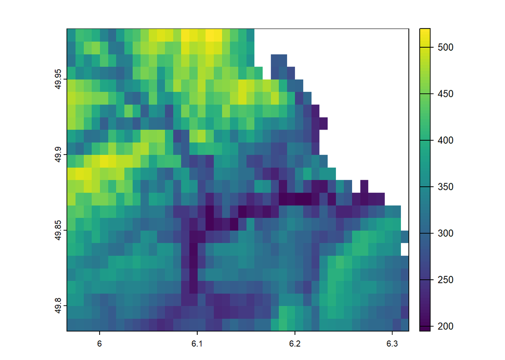

```r
przyciety_3 <- crop(luksemburg, przyciety_2)
plot(przyciety_3)
```

- maskowanie rastra bez przycinania

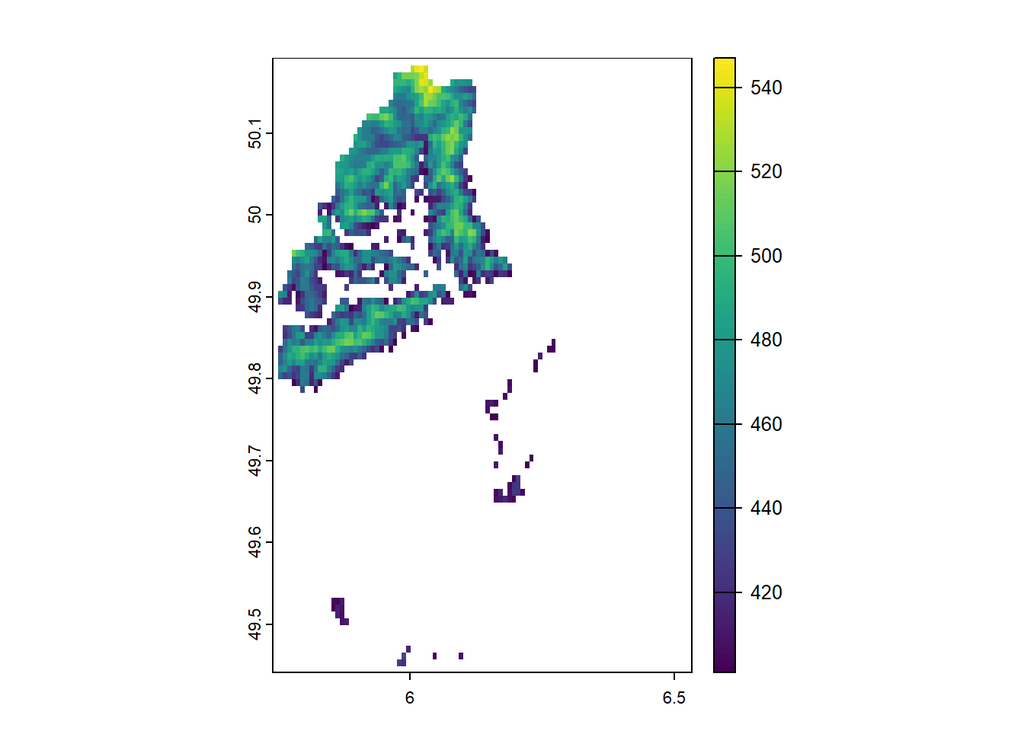

```r
raster_pow_400 <- luksemburg > 400
raster_pow_400 <- mask(luksemburg, raster_pow_400, maskvalues = FALSE)
plot(raster_pow_400)
```

### Statystyki strefowe

W przypadku danych rastrowych statystyki strefowe są obliczane zarówno w oparciu o strefy warstw poligonowych, jak i warstw rastrowych. Służy do tego ta sama funkcja, co w przypadku wektorów – `zonal()`. W przypadku rastrów zamieniamy jednak parametr `as.polygons` na `as.raster`, aby warstwą wynikową był raster z obliczonymi wartościami w poszczególnych strefach.

- statystyki strefowe dla poligonów, np. średnia wysokość rzeźby terenu w każdym kantonie:

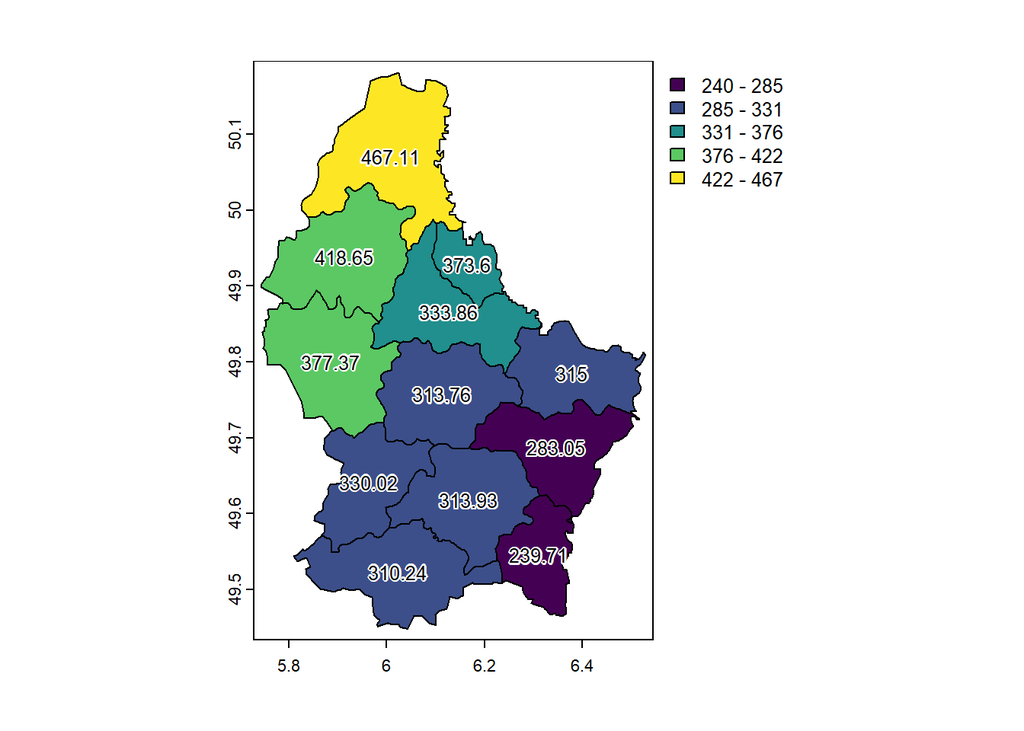

```r
stat_strefowe_poligonow <- terra::zonal(luksemburg, kantony, fun = "mean", as.polygons=TRUE, na.rm = TRUE)
stat_strefowe_poligonow$elevation <- round(stat_strefowe_poligonow$elevation, 2)

plot(stat_strefowe_poligonow, "elevation")
text(stat_strefowe_poligonow, "elevation", halo = TRUE, cex = 0.8)
```

- statystyki strefowe dla rastrów, np. średnia wysokość rzeźby terenu w każdej zreklasyfikowanej klasie (nizinach, wzniesieniach, wyżynach):

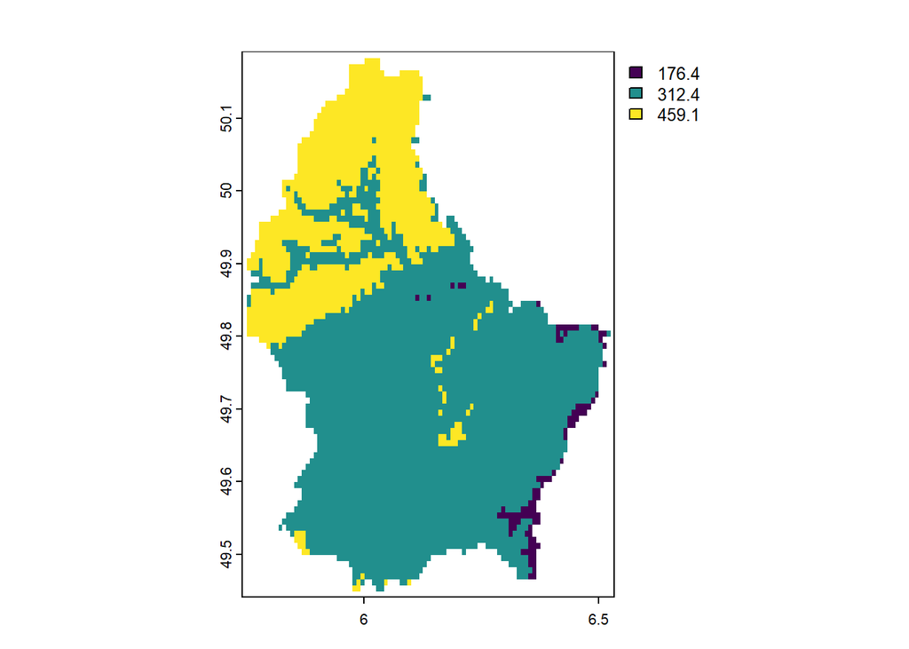

```r
stat_strefowe_rastrow <- terra::zonal(luksemburg, luksemburg_reclass, fun = "mean", as.raster=TRUE, na.rm = TRUE)
plot(stat_strefowe_rastrow)
```

### Poligonizacja

W zależności od celu analizy, dane rastrowe (najczęściej kategoryczne) można zamienić na poligony w oparciu o prezentowaną zmienną. Służy do tego funkcja `as.polygons()`. Warto przyjrzeć się dokumentacji tej funkcji (`?as.polygons`), aby sprawdzić najważniejsze parametry – funkcja pozwala także na agregację poligonów o identycznej wartości lub zaokrąglenie wartości.

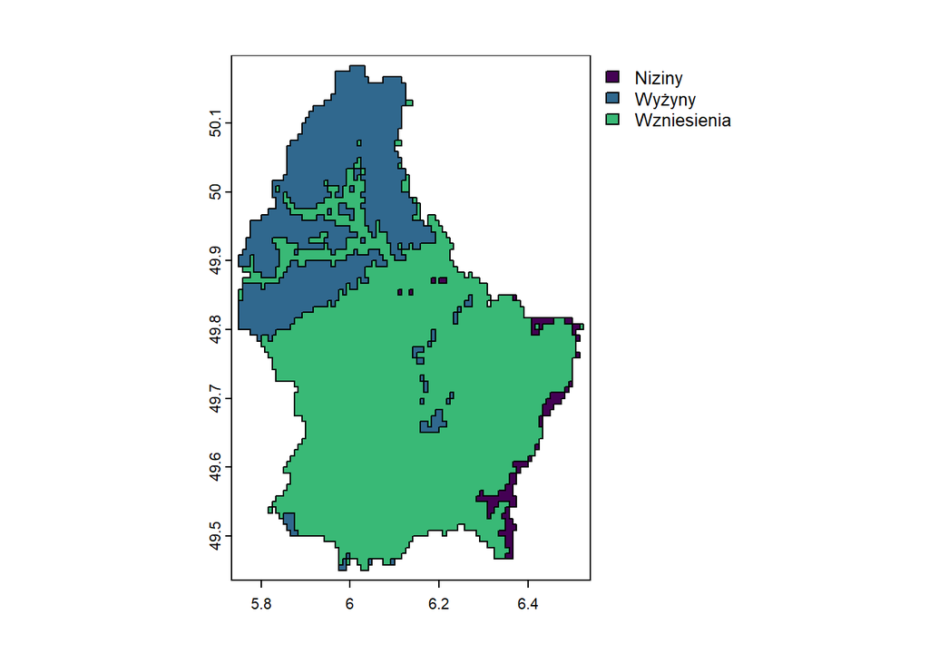

```r
luksemburg_poligon <- as.polygons(luksemburg_reclass)
plot(luksemburg_poligon, "label")
```

Mając warstwę poligonową można wykonywać wszelkie operacje na wektorach lub na ramkach danych. m.in. obliczenie powierzchni:

```r
pow_klas_df <- data.frame(forma_terenu = luksemburg_poligon$label,
              powierzchnia = round(expanse(luksemburg_poligon)/1000000, 3))
pow_klas_df
```

```
  forma_terenu powierzchnia
1       Niziny       53.561
2  Wzniesienia     1835.655
3       Wyżyny      674.393
```

### Próbkowanie rastra

Próbkowanie rastra (sampling) to wybieranie podzbioru pikseli polegające na wyodrębnieniu wartości rastra i przypisaniu do warstwy punktowej. Jest to powszechnie stosowana technika w celu m.in. zmniejszenia wielkości danych, uzyskania reprezentatywnej próbki z rastra, czy też ekstrakcji wartości pikseli do dalszych analiz. Do próbkowania pikseli służy funkcja `extract()`.

```r
# utworzenie losowego zbioru punktów
punkty <- spatSample(luksemburg_poligon, size = 50, method = "random")

# pobranie wartości pikseli z rastra
probka <- extract(luksemburg, punkty, xy=TRUE)
head(probka)
```

```
  ID elevation        x        y
1  1       224 6.262500 49.51250
2  2       279 6.320833 49.62083
3  3       319 6.004167 49.57083
4  4       330 5.962500 49.62083
5  5       449 5.904167 49.95417
6  6       336 5.904167 49.69583
```

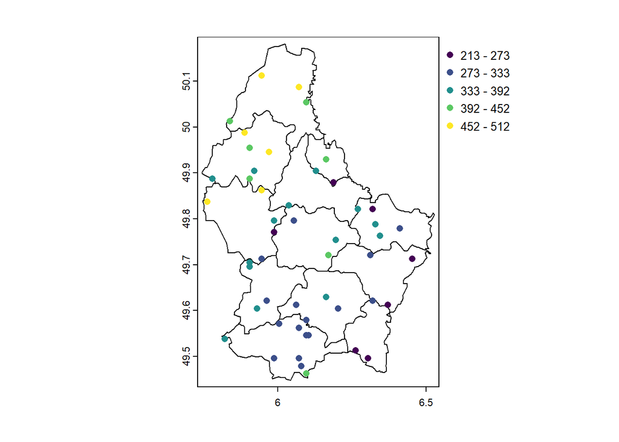

```r
probka <- vect(probka, geom = c("x", "y"))

plot(kantony)
plot(probka, "elevation", add = TRUE)
```

### Podstawowe statystyki

Podstawowymi statystykami są tzw. statystyki globalne, służące wyliczeniu statystyk komórek rastra – liczby pikseli, liczności pikseli w kategoriach, średniej wartości rastra, czy też sumy wartości. W pakiecie `terra` służy do tego funkcja `global()` której rezultatem jest ramka danych z obliczonymi statystykami. Użytecznymi funkcjami są także `ncell()` (liczba pikseli) oraz `freq()` zwracająca liczbę pikseli dla kategorii.

- **suma, średnia, minimum, maksimum**:

```r
global(luksemburg, c("sum", "min", "max", "mean"), na.rm=TRUE)
```

```
              sum min max     mean
elevation 1605135 141 547 348.3366
```

- **liczba pikseli**:

```r
# liczba wszystkich pikseli
ncell(luksemburg)
```

```
[1] 8550
```

```r
ncell(luksemburg) == dim(luksemburg)[1] * dim(luksemburg)[2]
```

```
[1] TRUE
```

```r
# liczba pikseli bez NA
global(luksemburg, fun = "notNA")
```

```
          notNA
elevation  4608
```

```r
paste0(round((global(luksemburg, fun = "notNA") / ncell(luksemburg)) * 100, 2),
       "% całego rastra posiada wartości w pikselach")
```

```
[1] "53.89% całego rastra posiada wartości w pikselach"
```

- **liczba pikseli dla poszczególnych wartości rastra** (szczególnie przydatne dla rastra kategorycznego):

```r
# raster z wysokością rzeźby terenu
freq(luksemburg) %>% head(5)
```

```
  layer value count
1     1   141     2
2     1   142     3
3     1   144     1
4     1   145     2
5     1   146     2
```

```r
# raster po reklasyfikacji z 3 kategoriami
freq(luksemburg_reclass)
```

```
  layer       value count
1     1      Niziny    96
2     1 Wzniesienia  3295
3     1      Wyżyny  1217
```

Mając informację o liczbie pikseli, a także o rozdzielczości lub powierzchni piksela, można obliczyć przybliżoną powierzchnię poszczególnych klas bez poligonizacji. Szybszą i bardziej intuicyjną opcją jest natomiast użycie poznanej już funkcji `expanse()` do obliczenia powierzchni, gdzie w przypadku danych rastrowych możemy wskazać strefy (zones), których piksele zliczy.

```r
pow_klas <- expanse(luksemburg_reclass, zones = luksemburg_reclass)
pow_klas
```

```
  layer        zone       area
1     1      Niziny   53559997
2     1 Wzniesienia 1835656783
3     1      Wyżyny  674393322
```

```r
pow_klas$area <- round(pow_klas$area/1000000, 3)
pow_klas_df$pow_rastra <- pow_klas$area

# porównanie powierzchni poligonowej i rastrowej klas
pow_klas_df
```

```
  forma_terenu powierzchnia pow_rastra
1       Niziny       53.561     53.560
2  Wzniesienia     1835.655   1835.657
3       Wyżyny      674.393    674.393
```

### Operacje topograficzne

Przy pomocy pakietu `terra` i funkcji `terrain()` możemy wykonać szereg analiz topograficznych jedynie w przypadku, kiedy posiadamy raster z wartościami wysokości rzeźby terenu. Funkcja ta pozwala na obliczenie m.in. nachylenia terenu (*slope*), ekspozycji (*aspect*), czy różnych indeksów topograficznych (np. TPI, TRI). Głównym interesującym nas parametrem jest zmiana wartości `v`, odpowiadającego za poszczególne charakterystyki terenu.

Dla uzyskania dokładniejszych wyników, operacje te przeprowadzimy w oparciu o wcześniejszy raster ze zwiększoną rozdzielczością.

- nachylenie terenu

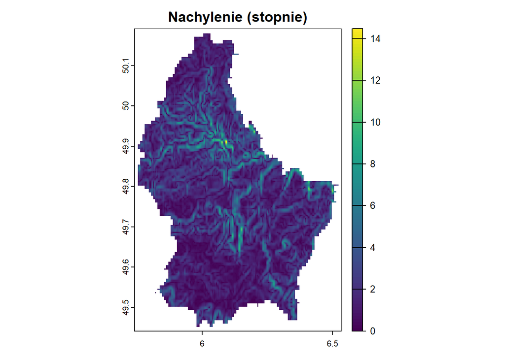

```r
slope <- terrain(luksemburg_disagg, v = "slope", unit = "degrees")
plot(slope, main = "Nachylenie (stopnie)")
```

- ekspozycja terenu

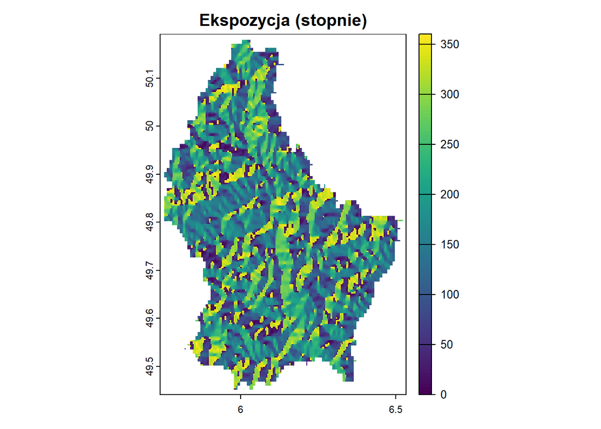

```r
aspect <- terrain(luksemburg_disagg, v = "aspect", unit = "degrees")
plot(aspect, main = "Ekspozycja (stopnie)")
```

### Wielokanałowość

Dane rastrowe mogą składać się z wielu kanałów (tzw. *bandów*), wówczas raster nazywa się rastrem wielokanałowym (*multiband*). Kanał to osobna warstwa danych zapisanych w tych samych pikselach, a więc każdy z nich posiada identyczny układ współrzędnych oraz zasięg, a w przypadku utworzonego rastra wielokanałowego za pomocą `terra` także rozdzielczość przestrzenną. Raster wielokanałowy można więc porównać do rastra przechowującego kilka zmiennych.

Najpowszechniejszymi rastrami wielokanałowymi są m.in. ortofotomapy przechowujące 3 kanały (RGB – czerwony, zielony i niebieski) oraz zdjęcia satelitarne składające się z kanałów RGB oraz dodatkowych kanałów spektralnych (np. kanał termalny lub panchromatyczny).

Przykładowy raster wielokanałowy można utworzyć z wcześniejszych operacji topograficznych, robiąc to w wektorze:

```r
raster_wielokanalowy <- terrain(luksemburg_disagg, v = c("slope", "aspect", "TPI", "TRI"))
```

Zbadanie liczby kanałów rastra może być wykonane głównie na dwa sposoby – poprzez zbadanie struktury, użycie funkcji `dim()` informującej o wymiarach rastra (liczba wierszy, liczba kolumn, liczba kanałów) lub użycie `nlyr()` – informacji o liczbie warstw. Aby zbadać ich nazwy, należy użyć funkcji `names()`.

```r
raster_wielokanalowy
```

```
class       : SpatRaster
dimensions  : 270, 285, 4  (nrow, ncol, nlyr)
resolution  : 0.002777778, 0.002777778  (x, y)
extent      : 5.741667, 6.533333, 49.44167, 50.19167  (xmin, xmax, ymin, ymax)
coord. ref. : lon/lat WGS 84 (EPSG:4326)
source(s)   : memory
names       :        slope, aspect,       TPI,        TRI
min values  : 1.590277e-15,      0, -36.22222,  0.1388931
max values  : 1.447532e+01,    360,  41.87500, 48.1954346
```

```r
dim(raster_wielokanalowy)
```

```
[1] 270 285   4
```

```r
nlyr(raster_wielokanalowy)
```

```
[1] 4
```

```r
names(raster_wielokanalowy)
```

```
[1] "slope"  "aspect" "TPI"    "TRI"
```

Wizualizując raster wielokanałowy możemy albo przedstawić wszystkie jego warstwy, albo wybrać tylko te interesujące, korzystając z `$`. W taki sam sposób (poprzez indeksowanie) możemy wyodrębnić któryś z kanałów do osbnej warstwy:

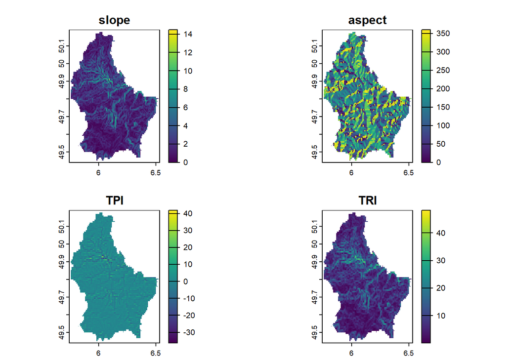

```r
plot(raster_wielokanalowy)
```

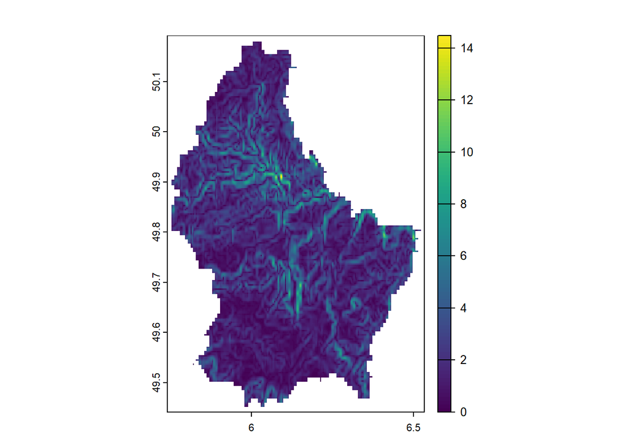

```r
plot(raster_wielokanalowy$slope)
```

```r
# wyodrębnienie tylko jednego kanału
aspect_2 <- raster_wielokanalowy$aspect
# LUB
aspect_2 <- raster_wielokanalowy[[1]]
dim(aspect_2)
```

```
[1] 270 285   1
```

Działanie na kanałach jest identyczne jak działanie na osobnych rastrach, a więc możliwe jest także wykonywanie wszelkich operacji algebraicznych.

### Wygładzanie rastra

W przypadku dość “szorstkich”, pełnych szumu rastrów, stosuje się czasami wygładzanie wartości, aby nakreślić pewną zmienność przestrzenną. W tym celu można zastosować funkcję `focal()`, która bierze pod uwagę otaczające piksele i zmienia wartość docelowego piksela na inną, w oparciu o wybraną statystykę. Funkcja ta jest wykonywana tzw. ruchomym oknem, co oznacza obliczanie wartości piksela w danym miejscu i przeskakiwanie na kolejny piksel, aż do przejścia całego zakresu rastra.

W zależności od typu rastra stosuje się różne funkcje ruchomego okna – w przypadku danych ciągłych korzysta się najczęściej ze średniej lub mediany, natomiast danych kategorycznych mody. Co ważne – operacja ta nie zmienia rozdzielczości rastra.

- dla wartości ciągłych:

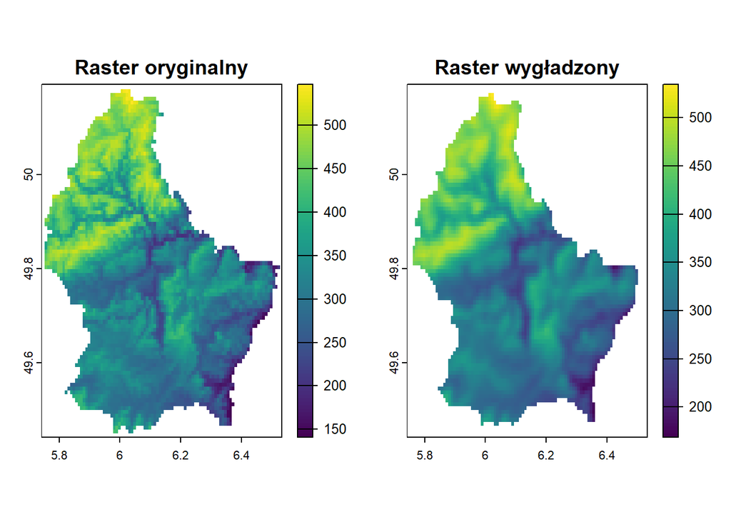

```r
focal_1 = focal(luksemburg, w = 3, fun = "mean")

par(mfrow = c(1, 2))
plot(luksemburg, main = "Raster oryginalny")
plot(focal_1, main = "Raster wygładzony")
```

- dla wartości kategorycznych:

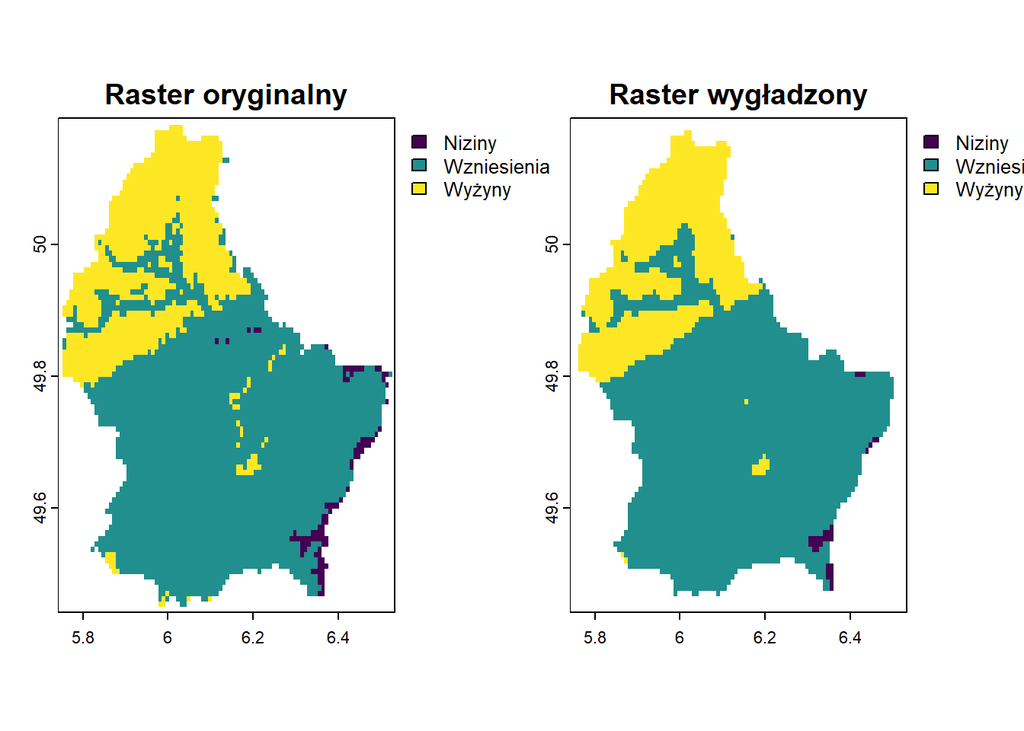

```r
focal_2 = focal(luksemburg_reclass, w = 3, fun = "modal")

par(mfrow = c(1, 2))
plot(luksemburg_reclass, main = "Raster oryginalny")
plot(focal_2, main = "Raster wygładzony")
```

# Wizualizacje map

### tmap

Poznany pakiet `tmap` pozwala na wizualizację rastrów w niemal identyczny sposób, co danych wektorowych, gdzie główną funkcją tworzącą obiekt jest `tm_raster()`.

Najprostsza wizualizacja może zatem wyglądać tak, jak poniżej:

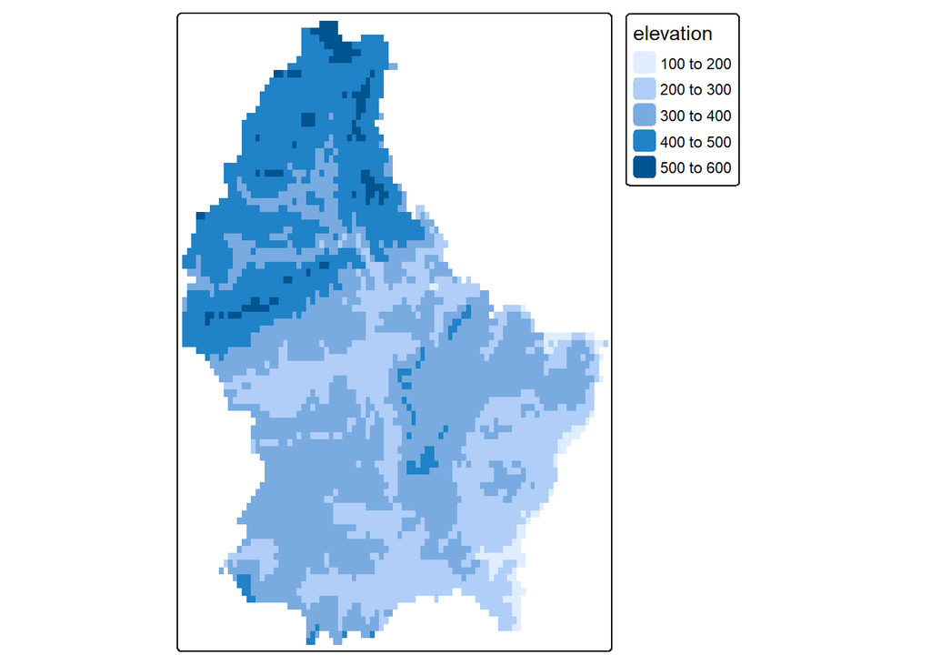

```r
library(tmap)

tm_shape(luksemburg) +
  tm_raster()
```

Wszelkie dodatkowe stylizacje warstwy zachodzą głównie w tej samej funkcji oraz funkcji `tm_layout()`. Dodatkowo można dodać zarówno strzałkę północy, jak i podziałkę liniową.

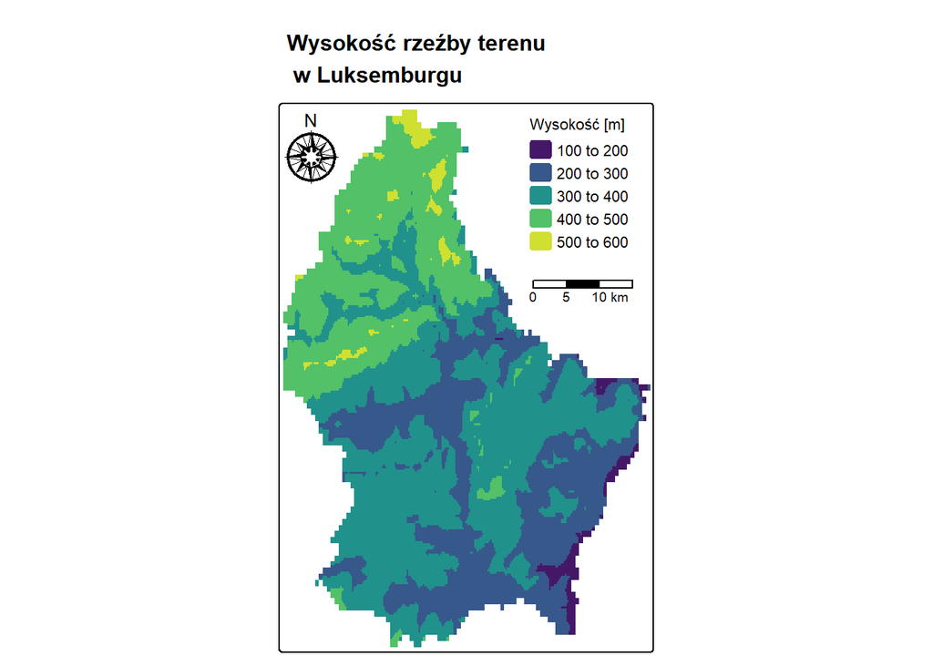

```r
tm_shape(luksemburg_disagg) +
  tm_raster(palette = "viridis", title = "Wysokość [m]") +
  tm_layout(main.title = "Wysokość rzeźby terenu\n w Luksemburgu",
            title.size = 1,
            title.fontface = "bold",
            legend.position = c(0.65, 0.99),
            legend.frame = FALSE,
            legend.height = 8,
            legend.width = 6,
            legend.title.size = 0.7) +
  tm_scale_bar(position = c(0.65, 0.7),
               text.size = 0.6,
               breaks = c(5, 10, 15)) +
  tm_compass(type = "rose",
             size = 2.5,
             position = c(-0.03, 1))
```